# Excercise 7

**7.** *A researcher collected daffodils from four sides of a building and from an open area nearby. She wondered whether the average stem length of a daffodil depends on its location. The data set is available as daffodils.csv from ILIAS.*

```r
library(readr)
daf <- read.csv("daffodils.csv", header = T)
str(daf)
```

```
## 'data.frame':    65 obs. of  2 variables:
##  $ Length: num  46 38 47 48 46 42.5 40.5 41.5 46.5 37.5 ...
##  $ Side  : Factor w/ 5 levels "East","North",..: 1 1 1 1 1 1 1 1 1 1 ...
```

**a)** *State the null hypothesis of an ANOVA model for this problem in words and as a formula.*

H0: “Daffodils grown on different sites have no significant difference in mean stem length.”

Y<sub>ij</sub> = μ + α<sub>i</sub> + E<sub>ij</sub>

H0: α<sub>1</sub>=α<sub>2</sub>=α<sub>3</sub>=α<sub>4</sub>=α<sub>5</sub>=0

**b)** *A boxplot of the data looks as follows:*

```
## notch went outside hinges. Try setting notch=FALSE.
## notch went outside hinges. Try setting notch=FALSE.
## notch went outside hinges. Try setting notch=FALSE.
```

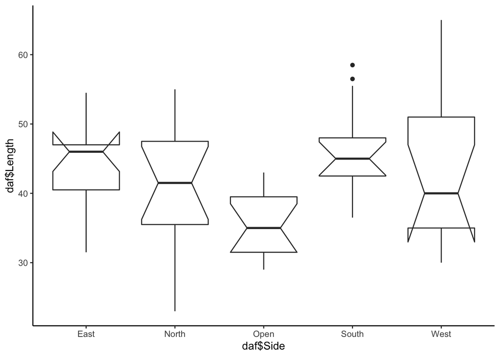

```r
library(ggplot2)
daf$Side <- as.factor(daf$Side)
ggplot() +
  geom_boxplot(aes(daf$Side, daf$Length), notch = T) +
  theme_classic()
```

*Based on the boxplot, does it appear that the null hypothesis is true?*

No, daffodils growing in the group “Open” seem to grow differently

**c)** *Fit an ANOVA model to the data and test the null hypothesis from a) on a significance level of 10%.*

```r
daf.fit <- lm(Length ~ Side, data = daf)
summary(daf.fit)
```

```
##
## Call:
## lm(formula = Length ~ Side, data = daf)
##
## Residuals:
##     Min      1Q  Median      3Q     Max
## -18.423  -5.038  -1.346   5.577  21.846
##
## Coefficients:
##             Estimate Std. Error t value Pr(>|t|)
## (Intercept)  43.8462     2.1449  20.442  < 2e-16 ***
## SideNorth    -2.4231     3.0334  -0.799  0.42755
## SideOpen     -8.3077     3.0334  -2.739  0.00811 **
## SideSouth     2.6538     3.0334   0.875  0.38513
## SideWest     -0.6923     3.0334  -0.228  0.82024
## ---
## Signif. codes:  0 '***' 0.001 '**' 0.01 '*' 0.05 '.' 0.1 ' ' 1
##
## Residual standard error: 7.734 on 60 degrees of freedom
## Multiple R-squared:  0.1954, Adjusted R-squared:  0.1417
## F-statistic: 3.642 on 4 and 60 DF,  p-value: 0.01009
```

“Open” daffodils are significantly different p = 0.008 (<10%). H0 is rejected since the effect of “Open” is unequal 0.

**d)** *Does the ANOVA model fit well to the data? Perform a residual analysis.*

```r
library(car)
```

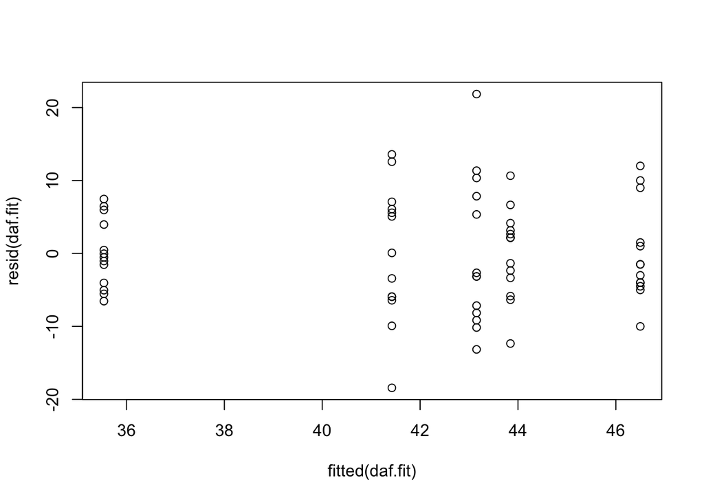

```r
plot(fitted(daf.fit), resid(daf.fit))
```

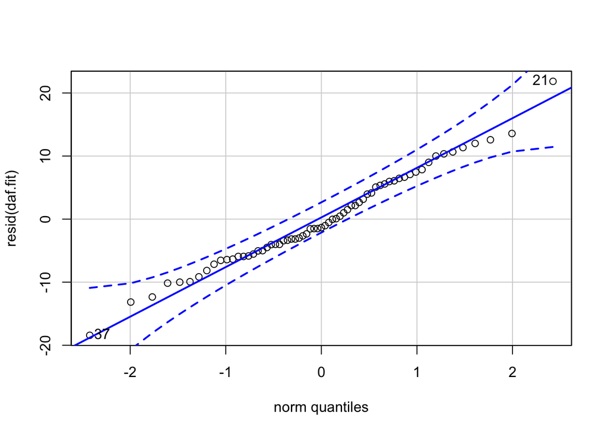

```
## [1] 21 37
```

```r
qqPlot(resid(daf.fit))
```

The Tukey-Ascombe plot shows a similar spread of fitted values. “Open” is slightly less scattered. The Q-Q plot shows normally distributed residuals. Overall the model assumptions are met.

**e)** *Which locations (sides of the building and open area) are not significantly different on a 5% level? Use Bonferroni adjusted pairwise t-tests.*

```r
pairwise.t.test (x=daf$Length, g=daf$Side, p.adj="bonf")
```

```
##
##  Pairwise comparisons using t tests with pooled SD
##
## data:  daf$Length and daf$Side
##
##       East   North  Open   South
## North 1.0000 -      -      -
## Open  0.0811 0.5709 -      -
## South 1.0000 0.9940 0.0062 -
## West  1.0000 1.0000 0.1477 1.0000
##
## P value adjustment method: bonferroni
```

“East”, “West”, “North”, “Open” and “South”, “East”, “West”, “North” are not significantly different on a 5% level.

only “South” vs “Open” is significantly different.